# Brechas Intergeneracionales, Género y Dinámica Macroeconómica: Un Análisis de la Precariedad y el Subempleo Laboral en Argentina (2004-2024)

Trabajo Integrador Final - Programación en R aplicada a la economía

Santiago Achucarro

2026-09-27

## 1. Resumen del trabajo

Este trabajo integrador final se propone investigar la evolución estructural de las desigualdades laborales en Argentina a lo largo de las últimas dos décadas (2004-2024). A través de un abordaje metodológico interseccional y cuantitativo que combina microdatos de la Encuesta Permanente de Hogares (EPH), se analiza cómo interactúan las dimensiones de género y los rangos etarios en la configuración de la precariedad salarial, el subempleo horario y la insuficiencia de ingresos en el bloque contemporáneo.

## 2. Introducción y Planteo del Problema

El estudio de los mercados de trabajo en América Latina y, de forma particular, en Argentina, se encuentra atravesado por debates teóricos históricos acerca de la naturaleza de la informalidad, la precariedad y el subempleo. Tradicionalmente, las fluctuaciones macroeconómicas han tendido a interpretarse como los principales vectores en la determinación de las tasas de ocupación y desempleo agregadas. Sin embargo, este análisis unidimensional omite que el entramado laboral no se comporta de manera homogénea, sino que se encuentra segmentado en su interior, distribuyendo los costos de las crisis económicas de forma asimétrica.

Este informe se centra en desentramar las desigualdades sociodemográficas latentes dentro de la población en edad central de trabajar (18 a 64 años). La relevancia de abordar la problemática laboral desde una perspectiva interseccional radica en que variables individuales como el sexo y la edad no actúan meramente como descriptores estadísticos aislados, sino que operan como principios ordenadores que estratifican el acceso a puestos de trabajo de calidad.

Para enriquecer el análisis conceptual propuesto en la cátedra, estructuramos este trabajo en base a tres ejes de investigación fundamentales: 1. **Dinámica Intertemporal del Registro:** ¿En qué medida los diferentes regímenes macroeconómicos ocurridos entre 2004, 2014 y 2024 lograron mitigar la informalidad salarial, o si esta conserva un núcleo duro de carácter estructural? 2. **El Fenómeno del Subempleo y la Precariedad por Edad:** ¿Actúa la inserción laboral precaria en los jóvenes como un trampolín transitorio hacia empleos estables o funciona como una trampa permanente que condiciona sus trayectorias futuras? 3. **La Pobreza Laboral e Interseccionalidad:** ¿De qué manera el género profundiza los niveles de vulnerabilidad frente a la insuficiencia de ingresos familiares en el contexto inflacionario actual?

Mediante la utilización del lenguaje de programación **R** y las funciones específicas provistas por la librería `{eph}`, este informe pretende brindar evidencia empírica rigurosa orientada a discutir críticamente las visiones productivistas y legalistas de la informalidad laboral en nuestro país.

## 3. Desarrollo Conceptual y Marco Teórico

Para dar respuesta a los disparadores sugeridos en las consignas teóricas de la diplomatura, resulta indispensable revisar brevemente la literatura económica y sociológica que define las dinámicas de registro y precarización en la región.

### 3.1 Criterios de Informalidad: Enfoque Productivista vs. Legalista

El análisis de la informalidad ha estado dominado por dos corrientes teóricas principales:

- **El Enfoque Productivista (PREALC / OIT):** Concibe a la informalidad como el resultado de una heterogeneidad estructural interna del aparato productivo. Bajo esta visión, el sector informal está constituido por unidades económicas de baja productividad, escasa capitalización y tecnologías rudimentarias (como el cuentapropismo de subsistencia o las microempresas familiares), donde los trabajadores se refugian ante la incapacidad del sector moderno de generar los puestos laborales necesarios.
- **El Enfoque Legalista o Institucionalista:** Centra su definición en el cumplimiento de los marcos normativos del Estado. Bajo este criterio, un trabajador es informal si su relación laboral carece de registro legal, evadiendo las regulaciones, los convenios colectivos y los aportes de la seguridad social (descuento jubilatorio).

En el desarrollo metodológico de este informe, se operacionalizan ambos criterios. El enfoque legalista se captura mediante la ausencia de aportes previsionales en asalariados, mientras que las dimensiones de la precariedad se expanden analizando el subempleo demandante y la pobreza de ingresos, reconociendo que la desprotección no es exclusiva del estatus de contratación, sino también de las dinámicas de remuneración y tiempo de trabajo.

### 3.2 Teorías Estructuralistas y la Inserción Juvenil (Efecto Cicatriz)

Siguiendo los planteos de Fernández Franco, Graña, Lastra y Weksler (2022), las teorías estructuralistas en América Latina demuestran que los procesos de modernización económica no han seguido los patrones lineales de convergencia previstos por las teorías neoclásicas. El mercado de trabajo tiende a dualizarse.

En esta segmentación, la población joven experimenta con mayor intensidad lo que la literatura denomina el **“Efecto Cicatriz”** (*scarring effect*). Ingresar al mercado de trabajo a través de puestos informales o subocupados durante la juventud no constituye necesariamente un paso transitorio o de aprendizaje. Por el contrario, la evidencia empírica regional sugiere que estas inserciones iniciales precarias tienden a penalizar las trayectorias de largo plazo, reduciendo la probabilidad de acceder a puestos formales estables en la adultez y perpetuando la segmentación del ingreso.

## 4. Metodología y Procesamiento de Datos

Los datos analizados corresponden a las bases de microdatos individuales de la **Encuesta Permanente de Hogares (EPH)** provista por el Instituto Nacional de Estadística y Censos (INDEC). A fin de aislar efectos coyunturales y consolidar tendencias robustas de largo plazo, se implementó una estrategia de descarga de cuatro ondas temporales utilizando la librería `{eph}` en R:

1. **Cuarto Trimestre de 2004:** Representa el período de post-crisis y reactivación económica con fuerte dinamismo salarial.
2. **Cuarto Trimestre de 2014:** Representa un punto de inflexión macroeconómica, con estancamiento en la generación de empleo registrado y tensiones cambiarias.
3. **Cuarto Trimestre de 2023** y **Primer Trimestre de 2024:** Bloque consolidado que captura las dinámicas sociolaborales de la actualidad macroeconómica reciente.

### 4.1 Definición y Operacionalización de Variables

Script en R:

```r
# 1. Cargo las librerías
library(tidyverse)
library(eph)

# 2. Evito la notación científica
options(scipen = 999)

# 3. Descargo los microdatos
base_2004_4 <- get_microdata(year = 2004, period = 4, type = "individual")
base_2014_4 <- get_microdata(year = 2014, period = 4, type = "individual")
base_2023_4 <- get_microdata(year = 2023, period = 4, type = "individual")
base_2024_1 <- get_microdata(year = 2024, period = 1, type = "individual")

# 4. Traigo las Líneas de Pobreza e Indigencia Regionalizadas
canasta <- get_poverty_lines(regional = TRUE)

# 5. Función de Armonización y Clasificación Demográfica Estructural
procesar_panel_completo <- function(df, tipo_base) {

  df_input <- df %>%
    mutate(ANO4 = as.numeric(ANO4), TRIMESTRE = as.numeric(TRIMESTRE))

  # Aplicamos el cálculo de pobreza únicamente para el bloque actual compatible
  if (tipo_base == "actual") {
    df_input <- calculate_poverty(base = df_input, basket = canasta, print_summary = FALSE)
  } else {
    df_input <- df_input %>% mutate(situacion = NA_character_)
  }

df_final <- df_input %>%
select(CODUSU, NRO_HOGAR, COMPONENTE, CH04, CH06, ESTADO,
CAT_OCUP, PP03J, PP07H, PONDERA, ANO4, situacion) %>%
mutate(
sexo_txt = if_else(CH04 == 1, "Varones", "Mujeres"),
edad = CH06,
ocupado = if_else(ESTADO == 1, 1, 0),

# Indicador de Informalidad Legalista
informal = if_else(ocupado == 1 & CAT_OCUP == 3 & PP07H == 2, 1, 0),
# Indicador de Subocupación Demandante
subocupado_demandante = if_else(ocupado == 1 & ESTADO == 1 & PP03J == 1, 1, 0),
# Definición de etiquetas temporales por ciclo político-económico
periodo = case_when(
ANO4 == 2004 ~ "Año 2004 (Post-Crisis)",
ANO4 == 2014 ~ "Año 2014 (Estancamiento)",
ANO4 %in% c(2023, 2024) ~ "Actualidad (2023-2024)"
),

# Construcción de Grupos Etarios Homogéneos
tramo_edad = case_when(
edad >= 18 & edad <= 29 ~ "Jóvenes (18-29)",
edad >= 30 & edad <= 49 ~ "Adultos (30-49)",
edad >= 50 & edad <= 64 ~ "Adultos Mayores (50-64)",
TRUE                    ~ "Fuera de rango"
),
# Matriz de condición socio-laboral contemporánea
estado_pob_lab = case_when(
tipo_base != "actual" ~ NA_character_,
ocupado == 1 & !situacion %in% c("indigente", "pobre") ~ "Trabajador No Pobre (TNP)",
ocupado == 1 & situacion %in% c("indigente", "pobre") ~ "Trabajador Pobre (TP)",
ocupado == 0 & situacion %in% c("indigente", "pobre") ~ "No Ocupado Pobre (NOP)",
ocupado == 0 & !situacion %in% c("indigente", "pobre") ~ "No Ocupado No Pobre (NONP)"
)
) %>%
# Filtramos la población fuera del rango etario central de análisis
filter(tramo_edad != "Fuera de rango")
return(df_final)
}

# 6. Procesamiento secuencial y consolidación final en un dataframe unificado

t04_limpia <- procesar_panel_completo(base_2004_4, tipo_base = "historica_04")
t14_limpia <- procesar_panel_completo(base_2014_4, tipo_base = "historica_14")
t23_limpia <- procesar_panel_completo(base_2023_4, tipo_base = "actual")
t24_limpia <- procesar_panel_completo(base_2024_1, tipo_base = "actual")
base_consolidada <- bind_rows(t04_limpia, t14_limpia, t23_limpia, t24_limpia)
```

## 5. Resultados y Análisis Empírico

### 5.1 Evolución de Largo Plazo de la Informalidad según Cohortes Etarias (2004-2024)

En primera instancia, se examina el comportamiento de la tasa de informalidad salarial a lo largo de las tres ventanas de análisis. Esta perspectiva histórica nos permite verificar si el crecimiento o contracción de la economía altera la brecha preexistente entre jóvenes y adultos.

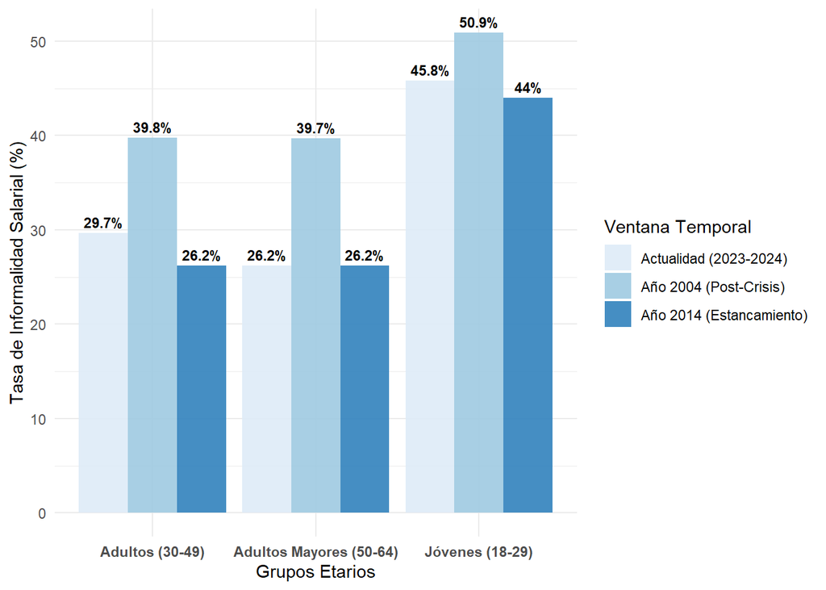

Evolución de la Tasa de Informalidad Asalariada por Tramo de Edad (2004 vs. 2014 vs. Actualidad)

El análisis del gráfico precedente arroja resultados concluyentes respecto a la rigidez del mercado laboral argentino.

En el año 2004, en un contexto de salida de la crisis de la convertibilidad, la informalidad juvenil alcanzaba un de por sí elevado 50.9%, superando de forma marcada los registros de los adultos (39.8%) y adultos mayores (39.7%).

La ventana contemporánea (Actualidad 2023-2024) demuestra una reversión del proceso de mejoras, exponiendo un incremento de la desprotección salarial en los jóvenes, donde la informalidad asciende al 45.8%.

Estos datos validan la hipótesis del estructuralismo latinoamericano: los jóvenes absorben de forma prioritaria los empleos desregulados, operando como un colchón de precarización ante la incapacidad de la estructura macroeconómica de absorber mano de obra bajo condiciones de registro legal.

### 5.2 El Subempleo Horario y la Precariedad de los Grupos Demográficos

A fin de profundizar sobre las formas que asume la precariedad más allá del criterio legalista del descuento jubilatorio, evaluamos la incidencia del **subempleo demandante**. Este indicador refleja la insuficiencia de horas de trabajo y la consecuente erosión del poder adquisitivo familiar de forma involuntaria.

Matriz de Indicadores de Precariedad y Subempleo por Tramo Etario en la Actualidad

| tramo_edad | Tasa Pobreza Laboral (%) | Tasa Informalidad Asalariada (%) | Subocupación Demandante (%) |
| --- | --- | --- | --- |
| Adultos (30-49) | 28.8 | 29.7 | 17.5 |
| Adultos Mayores (50-64) | 22.2 | 26.2 | 12.1 |
| Jóvenes (18-29) | 27.2 | 45.8 | 23.1 |

El cuadro estadístico revela una correspondencia estrecha entre la edad y las múltiples dimensiones de la vulnerabilidad.

Los jóvenes no solo sufren la tasa de informalidad más elevada (45.8%), sino que a su vez registran los niveles más altos de subocupación involuntaria (23.1%).

Esto implica que la juventud activa se enfrenta a un doble obstáculo: dificultades severas para ingresar al sector registrado y, simultáneamente, restricciones para consolidar una jornada laboral completa que les provea ingresos estables.

Esta fragilidad de inserción se traslada de forma directa sobre el bienestar del hogar, reflejándose en una tasa de Pobreza Laboral del 27.2% para la cohorte de menor edad.

A continuación, el gráfico de barras apiladas detalla la composición interna sociolaboral actual de la población para cada rango de edad bajo estudio:

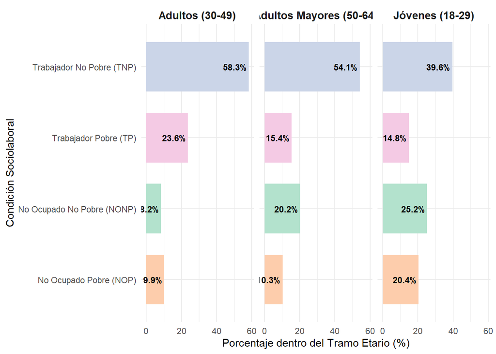

Composición Socio-Laboral de la Población según Rango de Edad Activa

### 5.3 Intersección de Género y Edad en la Configuración de la Pobreza Laboral

Por último, el informe indaga sobre el principio de la interseccionalidad. Evaluamos de qué manera el género introduce penalizaciones adicionales sobre la población ocupada activa, agravando la probabilidad de caer bajo la línea de pobreza aun teniendo un puesto de trabajo.

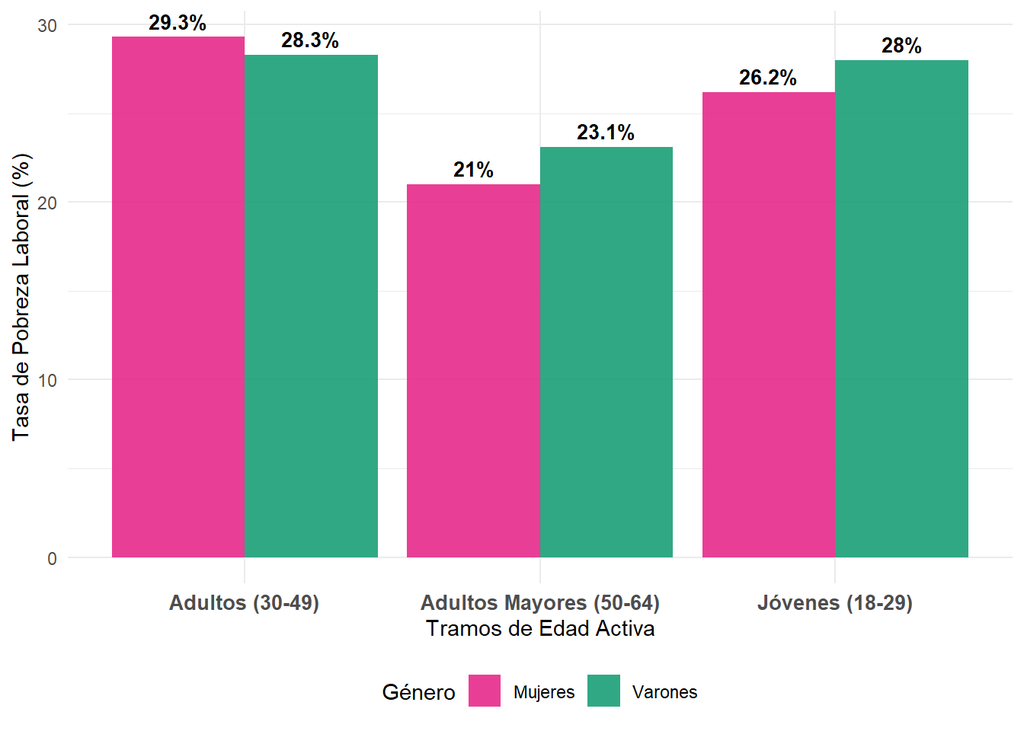

Incidencia del Fenómeno del Trabajador Pobre por Género y Cohorte Etaria Activa

El gráfico de brecha expone con nitidez cómo interactúan la edad y el género en la configuración de la pobreza laboral.

En la cohorte de Adultos (30-49 años), las mujeres ocupadas presentan una tasa de pobreza laboral que supera a sus pares varones, alcanzando el 29.3% frente al 28.3%.

Por el contrario, en el tramo de Adultos Mayores (50-64 años) la relación se invierte de forma leve, registrándose un 23.1% de pobreza laboral en los varones frente a un 21% en las mujeres.

Por su parte, la cohorte de Jóvenes (18 a 29 años) exhibe niveles críticamente altos de vulnerabilidad para ambos géneros, donde la pobreza laboral se sitúa en un 26.2% para las mujeres y un 28% para los varones.

## 6. Conclusiones

A lo largo de este informe integrador, hemos evaluado empíricamente la dinámica del mercado de trabajo argentino bajo una mirada histórica, de ciclo etario e interseccional de género, cumpliendo con los objetivos conceptuales previstos.

En términos de políticas públicas, los datos sugieren la necesidad de abandonar las estrategias de empleo genéricas y avanzar hacia regulaciones e incentivos de inserción laboral focalizados, que reconozcan las barreras específicas de género y edad que traban el acceso equitativo a puestos de trabajo de calidad en nuestro país.